# HW4

2021-12-07

## 1. 讀取需要使用的套件

```r
library(tidyverse)
library(jiebaR)
library(ropencc)
```

## 2. 讀入檔案

使用審計部的資料：nao.RData。請從NTU COOL中的文件 -> 03_code -> data 內下載。

```r
load(file = "data/nao.RData")
```

## 3. 斷詞並移除所有數字

請先完成斷詞（fulltext欄位），再移除所有數字。

```r
# 初始化斷詞引擎
tokenizer <- worker(bylines = 1)

#移除所有數字後斷詞
data_tokenized <- data_all %>%
    mutate(fulltext = str_replace_all(string = fulltext,
                                    pattern = "[0-9]+",
                                    replacement = "")) %>%
    mutate(tokens = segment(code = fulltext,
                           jiebar = tokenizer)) %>%
    unnest() # 將tokens(list column)展開，令每一列都只有一個token。
# 檢查
class(data_tokenized$fulltext)
```

```
## [1] "character"
```

```r
class(data_tokenized$tokens)
```

```
## [1] "character"
```

## 4. 移除停用字

建立中文停用字，並且加入（“年”, “月”, “日”, “民國”, “與”, “於”, “並”, “為”, “項”）為停用字。可使用stopwords套件建立中文停用字data frame，並再加上前述提到的字。

```r
# 載入停詞字典，並將停詞字典簡轉繁
zh_stopwords <- tibble(stopword = stopwords::stopwords(language = "zh", source = "misc"))
trans <- converter(S2TWP)
zh_stopwords$stopword <- run_convert(trans, zh_stopwords$stopword)

# 自訂停詞(因為是先去除數字才斷詞，所以"年", "月", "日"可能會合併成"年月日"，故新增此項)
custom <- tibble(stopword = c("年", "月", "日", "民國", "與", "於", "並", "為", "項", "年月日"))
custom_stopwords <- rbind(zh_stopwords, custom)

# 去除停詞
data_token_clean <- data_tokenized %>%
    anti_join(custom_stopwords, by = c("tokens" = "stopword"))
```

## 5. 繪圖

計算每年最常出現的前10個字（次數即可），並將每年繪製成一張小圖（facet_wrap）。請注意務必完成以下幾點：

1. 選出每年最常出現的10個字及計算相對應的字數；
2. 最後呈現時，x軸為次數，y為常用字（提示：coord_flip）；
3. 每年的bar塗上不同顏色，並移除旁邊年份的整個圖示說明（legend）；
4. 每年繪製一張小圖（facet_wrap），並依照各年不同數據差異調整尺度；
5. 請自行加上x軸、y軸名稱，以及圖名；
6. 挑選一個你喜歡的theme更換（使用Mac系統的同學請注意顯示中文字體要另外調整）。
7. 請確認圖會展示在html檔中。

不用像我提供的圖一樣依照次數排序，那是要另外處理才能作到的。

```r
top10_year <- data_token_clean %>%
    # 篩出year的變項，並清理dataframe
    mutate(year = str_extract(string = date,
                              pattern = "\\d{4}")) %>%
    select(title, year, tokens) %>%
    # 按年分組計算並挑選出前十高詞頻
    group_by(year) %>%
    count(tokens) %>%
    arrange(desc(n)) %>%
    slice_head(n = 10) %>%
    ungroup()
```

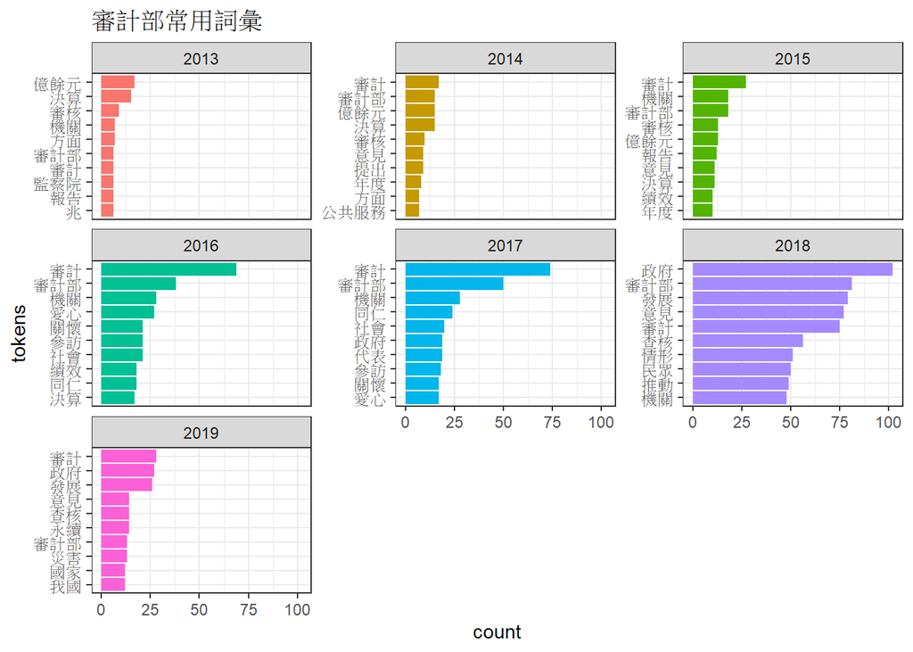

```r
ggplot(top10_year) +
    geom_bar(aes(x=tidytext::reorder_within(x = tokens, by = n, within = year), y=n, fill = year), stat = "identity") +
    tidytext::scale_x_reordered() +
    # 以year為類別變項繪製圖表
    facet_wrap(vars(year), scales = "free_y") +
    # 增加標題、xy軸名稱
    labs(title = "審計部常用詞彙",
         x = "tokens",
         y = "count") +
    # 翻轉xy軸
    coord_flip() +
    # 更改主題樣式
    theme_bw() +
    # 移除圖例
    theme(legend.position = "none")
```